# R Notebook

An R list is an object consisting of an ordered collection of objects known as its components. There is no particular need for the components to be of the same mode or type, and, for example, a list could consist of a numeric vector, a logical value, a matrix, a complex vector, a character array, a function, and so on.

```r
Lst <- list(name="Fred", wife="Mary", no.children=3, child.ages=c(5,7,10))
print(Lst)
```

```
$name
[1] "Fred"

$wife
[1] "Mary"

$no.children
[1] 3

$child.ages
[1]  5  7 10
```

```r
Lst[[1]]
```

```
[1] "Fred"
```

```r
Lst[[4]][[1]]
```

```
[1] 5
```

```r
list <- as.list(netflix$genres)
string <- toString(list)
genres <- str_extract_all(string, "[a-z]+")
list_of_genres <- as.data.frame(genres, col.names = c("genre"))
top_genres <- list_of_genres %>%
  group_by(genre) %>%
  summarise(count = n())  %>%
  arrange(desc(count))
```

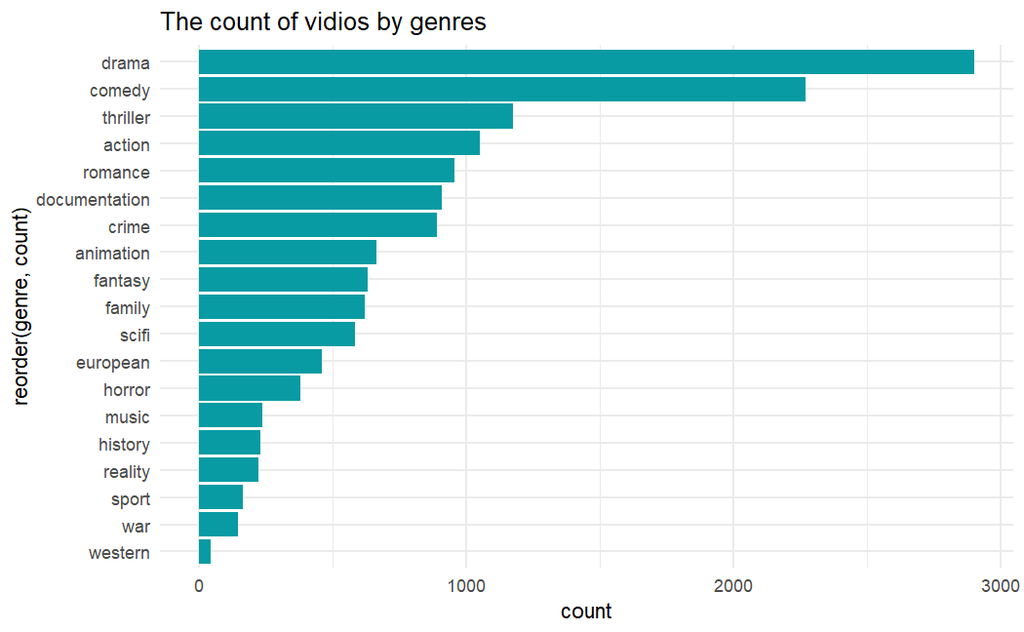

```r
ggplot(top_genres)+
  geom_col(aes(count, reorder(genre, count)), fill="#089BA3")+
  theme_minimal()+
  labs(title = "The count of vidios by genres")
```

IMDB score

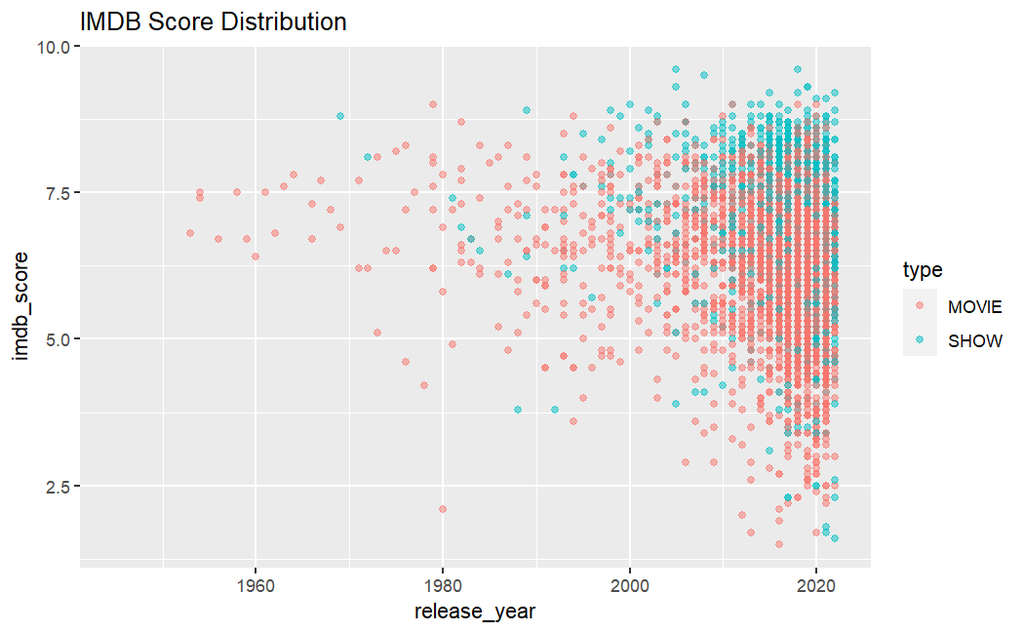

```r
ggplot(netflix) +
  geom_point(aes(release_year, imdb_score, color=type), alpha = 0.5) +
  labs(title = "IMDB Score Distribution")
```

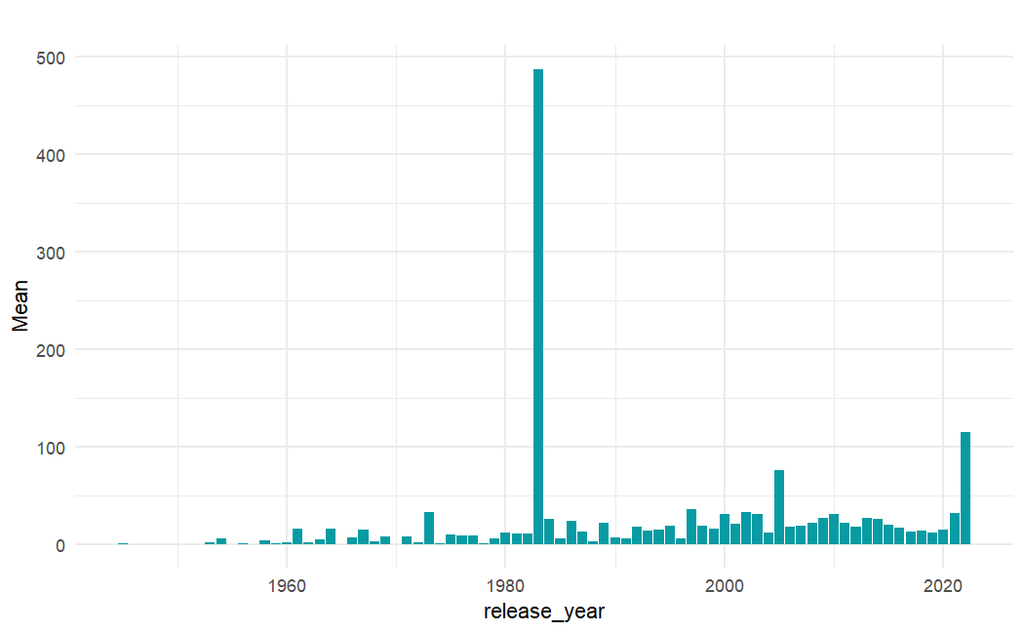

```r
netflix %>%
  filter(!is.na(tmdb_popularity)) %>%
  group_by(release_year) %>%
  summarise(Mean = mean(tmdb_popularity)) %>%
  ggplot()+
  geom_col(aes(release_year, Mean), fill="#089BA3")+
  theme_minimal()+
  labs(title = "")
```

```r
netflix$decade = NA

for (i in 1:dim(netflix)[1])  {
  netflix$decade[i] = netflix$release_year[i] - netflix$release_year[i] %% 10
}
```

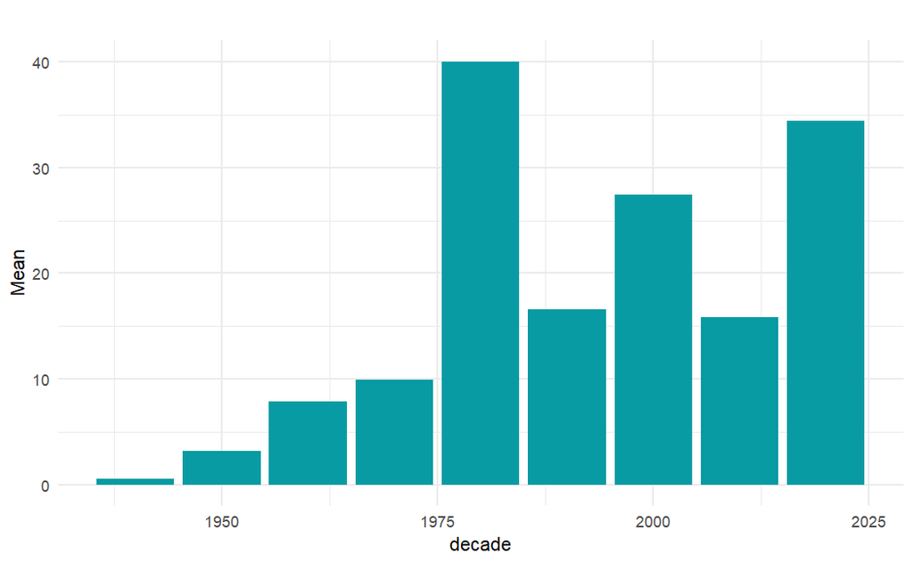

```r
netflix %>%
  filter(!is.na(tmdb_popularity)) %>%
  group_by(decade) %>%
  summarise(Mean = mean(tmdb_popularity)) %>%
  ggplot()+
  geom_col(aes(decade, Mean), fill="#089BA3")+
  theme_minimal()+
  labs(title = "")
```

EXTRA for the curious and brave ones

```r
library(wordcloud)
library(tidytext)
desc_words_m <- netflix %>%
  filter(type == "MOVIE" ) %>%
    unnest_tokens(word, description) %>%
    anti_join(stop_words)
count_word <- desc_words_m %>%
   count(word, sort = TRUE)
```

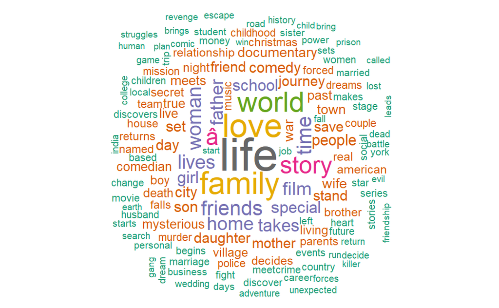

```r
wordcloud(words = count_word$word,
          freq = count_word$n,
          min.freq = 50,
          max.words = nrow(count_word),
          random.order = FALSE,
          rot.per = 0.1,
          colors = brewer.pal(8, "Dark2")
)
```